# Trabajo_Personal

Jon Santamaria

1/24/2022

Para poder realizar el trabajo, en primer lugar instalamos el paquete nycflights13

```r
library(nycflights13)
library(lubridate)
library(tidyverse)
```

1. Encuentra todos los vuelos que llegaron más de una hora tarde de lo previsto.

```r
vuelos= nycflights13::flights
vuelos_buenos= vuelos[complete.cases(vuelos),]
?flights

retrasos= vuelos[which(vuelos$arr_delay> 60), ]
a=dim(retrasos)
a[1]
```

```
## [1] 27789
```

```r
print(paste0("Hay ", a[1], " vuelos que llegaron con retraso"))
```

```
## [1] "Hay 27789 vuelos que llegaron con retraso"
```

2. Encuentra todos los vuelos que volaron hacia San Francisco (aeropuertos SFO y OAK)

```r
vSF= vuelos[vuelos$dest== "SFO" | vuelos$dest== "OAK",]
a=dim(vSF)
a[1]
```

```
## [1] 13643
```

```r
print(paste0("Hay ", a[1], " vuelos que volaron hacia San Francisco"))
```

```
## [1] "Hay 13643 vuelos que volaron hacia San Francisco"
```

3. Encuentra todos los vuelos operados por United American (UA) o por American Airlines (AA)

```r
vOp= vuelos[vuelos$carrier == "UA" | vuelos$carrier == "AA",]
a=dim(vOp)
a[1]
```

```
## [1] 91394
```

```r
print(paste0("Hay ", a[1], " vuelos que volaron operados por United American (UA) o por American Airlines (AA)"))
```

```
## [1] "Hay 91394 vuelos que volaron operados por United American (UA) o por American Airlines (AA)"
```

4. Encuentra todos los vuelos que salieron los meses de primavera (Abril, Mayo y Junio)

```r
vPrim= vuelos[vuelos$month=="4" | vuelos$month=="5" | vuelos$month=="6",]
a=dim(vPrim)
a[1]
```

```
## [1] 85369
```

```r
print(paste0("Hay ", a[1], " vuelos que volaron en los meses de primavera"))
```

```
## [1] "Hay 85369 vuelos que volaron en los meses de primavera"
```

5. Encuentra todos los vuelos que llegaron más de una hora tarde pero salieron con menos de una hora de retraso.

```r
retrasados2= vuelos[which(vuelos$arr_delay> 60 & vuelos$dep_delay< 60), ]
a=dim(retrasados2)
a[1]
```

```
## [1] 4956
```

```r
print(paste0("Hay ", a[1], " vuelos que llegaron con mas de una hora de retraso y salieron con menos de una hora de retraso"))
```

```
## [1] "Hay 4956 vuelos que llegaron con mas de una hora de retraso y salieron con menos de una hora de retraso"
```

6. Encuentra todos los vuelos que salieron con más de una hora de retraso pero consiguieron llegar con menos de 30 minutos de retraso (el avión aceleró en el aire)

```r
retrasados3= vuelos[which(vuelos$arr_delay< 30 & vuelos$dep_delay> 60), ]
a=dim(retrasados3)
a[1]
```

```
## [1] 181
```

```r
print(paste0("Hay ", a[1], " vuelos que llegaron con menos de 30 minutos de retraso y salieron con más de una hora de retraso"))
```

```
## [1] "Hay 181 vuelos que llegaron con menos de 30 minutos de retraso y salieron con más de una hora de retraso"
```

7. Encuentra todos los vuelos que salen entre medianoche y las 7 de la mañana (vuelos nocturnos).

```r
vnocturnos= vuelos[which(vuelos$hour>=0 & vuelos$hour<=7 ),]
a=dim(vnocturnos)
a[1]
```

```
## [1] 50726
```

```r
print(paste0("Hay ", a[1], " vuelos nocturnos"))
```

```
## [1] "Hay 50726 vuelos nocturnos"
```

8. ¿Cuántos vuelos tienen un valor desconocido de dep_time?

```r
vNA= vuelos[is.na(vuelos$dep_time),]
a=dim(vNA)
a[1]
```

```
## [1] 8255
```

```r
print(paste0("Hay ", a[1], " vuelos con valores desconocidos"))
```

```
## [1] "Hay 8255 vuelos con valores desconocidos"
```

9. ¿Qué variables del dataset contienen valores desconocidos?

```r
apply(X=is.na(vuelos), MARGIN= 2, FUN=sum)
```

```
##           year          month            day       dep_time sched_dep_time
##              0              0              0           8255              0
##      dep_delay       arr_time sched_arr_time      arr_delay        carrier
##           8255           8713              0           9430              0
##         flight        tailnum         origin           dest       air_time
##              0           2512              0              0           9430
##       distance           hour         minute      time_hour
##              0              0              0              0
```

```r
print("Las variables que tienen valores desconocidos son: dep_time, dep_delay, arr_time, arr_delay, tailnum y air_time")
```

```
## [1] "Las variables que tienen valores desconocidos son: dep_time, dep_delay, arr_time, arr_delay, tailnum y air_time"
```

10. Ordena los vuelos de flights para encontrar los vuelos más retrasados en la salida. ¿Qué vuelos fueron los que salieron los primeros antes de lo previsto?

```r
# Los más retrasados
vordenados= vuelos[order(vuelos$dep_delay, na.last = F),]
tail(vordenados)
```

```
## # A tibble: 6 × 19
##    year month   day dep_time sched_dep_time dep_delay arr_time sched_arr_time
##   <int> <int> <int>    <int>          <int>     <dbl>    <int>          <int>
## 1  2013     4    10     1100           1900       960     1342           2211
## 2  2013     7    22      845           1600      1005     1044           1815
## 3  2013     9    20     1139           1845      1014     1457           2210
## 4  2013     1    10     1121           1635      1126     1239           1810
## 5  2013     6    15     1432           1935      1137     1607           2120
## 6  2013     1     9      641            900      1301     1242           1530
## # … with 11 more variables: arr_delay <dbl>, carrier <chr>, flight <int>,
## #   tailnum <chr>, origin <chr>, dest <chr>, air_time <dbl>, distance <dbl>,
## #   hour <dbl>, minute <dbl>, time_hour <dttm>
```

```r
# Los mas adelantados
v_adelantados=vuelos[order(vuelos$dep_delay),]
head(v_adelantados)
```

```
## # A tibble: 6 × 19
##    year month   day dep_time sched_dep_time dep_delay arr_time sched_arr_time
##   <int> <int> <int>    <int>          <int>     <dbl>    <int>          <int>
## 1  2013    12     7     2040           2123       -43       40           2352
## 2  2013     2     3     2022           2055       -33     2240           2338
## 3  2013    11    10     1408           1440       -32     1549           1559
## 4  2013     1    11     1900           1930       -30     2233           2243
## 5  2013     1    29     1703           1730       -27     1947           1957
## 6  2013     8     9      729            755       -26     1002            955
## # … with 11 more variables: arr_delay <dbl>, carrier <chr>, flight <int>,
## #   tailnum <chr>, origin <chr>, dest <chr>, air_time <dbl>, distance <dbl>,
## #   hour <dbl>, minute <dbl>, time_hour <dttm>
```

11. Ordena los vuelos de flights para encontrar los vuelos más rápidos. Usa el concepto de rapidez que consideres.

```r
vuelos$velocidad=(vuelos$distance/vuelos$air_time)
v_rap=vuelos[order(vuelos$velocidad, na.last = F),]
# Estos son los vuelos más rápidos basandonos en la velocidad
tail(v_rap)
```

```
## # A tibble: 6 × 20
##    year month   day dep_time sched_dep_time dep_delay arr_time sched_arr_time
##   <int> <int> <int>    <int>          <int>     <dbl>    <int>          <int>
## 1  2013    11    17      650            655        -5     1059           1150
## 2  2013     1    12     1559           1600        -1     1849           1917
## 3  2013     3    23     1914           1910         4     2045           2043
## 4  2013     5    13     2040           2025        15     2225           2226
## 5  2013     7     2     1558           1513        45     1745           1719
## 6  2013     5    25     1709           1700         9     1923           1937
## # … with 12 more variables: arr_delay <dbl>, carrier <chr>, flight <int>,
## #   tailnum <chr>, origin <chr>, dest <chr>, air_time <dbl>, distance <dbl>,
## #   hour <dbl>, minute <dbl>, time_hour <dttm>, velocidad <dbl>
```

12. ¿Qué vuelos tienen los trayectos más largos?

```r
v_trayecto=vuelos[order(vuelos$distance, decreasing = T),]
head(v_trayecto)
```

```
## # A tibble: 6 × 20
##    year month   day dep_time sched_dep_time dep_delay arr_time sched_arr_time
##   <int> <int> <int>    <int>          <int>     <dbl>    <int>          <int>
## 1  2013     1     1      857            900        -3     1516           1530
## 2  2013     1     2      909            900         9     1525           1530
## 3  2013     1     3      914            900        14     1504           1530
## 4  2013     1     4      900            900         0     1516           1530
## 5  2013     1     5      858            900        -2     1519           1530
## 6  2013     1     6     1019            900        79     1558           1530
## # … with 12 more variables: arr_delay <dbl>, carrier <chr>, flight <int>,
## #   tailnum <chr>, origin <chr>, dest <chr>, air_time <dbl>, distance <dbl>,
## #   hour <dbl>, minute <dbl>, time_hour <dttm>, velocidad <dbl>
```

13. ¿Qué vuelos tienen los trayectos más cortos?

```r
v_trayecto=vuelos[order(vuelos$distance, decreasing = F),]
tail(v_trayecto)
```

```
## # A tibble: 6 × 20
##    year month   day dep_time sched_dep_time dep_delay arr_time sched_arr_time
##   <int> <int> <int>    <int>          <int>     <dbl>    <int>          <int>
## 1  2013     9    23      955           1000        -5     1437           1445
## 2  2013     9    25     1001           1000         1     1508           1445
## 3  2013     9    27      951           1000        -9     1442           1445
## 4  2013     9    28      955           1000        -5     1412           1445
## 5  2013     9    29      957           1000        -3     1405           1445
## 6  2013     9    30      959           1000        -1     1438           1445
## # … with 12 more variables: arr_delay <dbl>, carrier <chr>, flight <int>,
## #   tailnum <chr>, origin <chr>, dest <chr>, air_time <dbl>, distance <dbl>,
## #   hour <dbl>, minute <dbl>, time_hour <dttm>, velocidad <dbl>
```

14. El dataset de vuelos tiene dos variables, dep_time y sched_dep_time muy útiles pero difíciles de usar por cómo vienen dadas al no ser variables continuas. Fíjate que cuando pone 559, se refiere a que el vuelo salió a las 5:59… Convierte este dato en otro más útil que represente el número de minutos que pasan desde media noche.

```r
vuelos$dep_time_min= (vuelos$dep_time %/%100*60 + vuelos$dep_time %%100)
vuelos$sched_dep_time_min= (vuelos$sched_dep_time %/%100*60 + vuelos$sched_dep_time %%100)
print("Hemos creado dos columnas dividiendo los valores entre 100 para poder multipicar por 60 el valor que quedaba por delante de la coma, que es el que corresponde a las horas. De esta manera, sumando los minutos correspondientes a los valores de la derecha de la coma con los minutos calculados a partir de las horas, obtenemos el tiempo total en minutos")
```

[output not shown]

15. Compara los valores de dep_time, sched_dep_time y dep_delay. ¿Cómo deberían relacionarse estos tres números? Compruébalo y haz las correcciones numéricas que necesitas.

```r
vuelos$relacion= (vuelos$dep_time_min - vuelos$sched_dep_time_min - (vuelos$dep_delay))
table(vuelos$relacion)
```

```
##
##  -1440      0
##   1207 327314
```

```r
print("Podemos correctamente la relaciones entre estas varibales en 327314 vuelos ya que en la resta obtenemos cero. Sin embrago, en 1207 vuelos no podemos observar correctamente esa relación ya que la resta nos da 1440, esto se debe a que el retraso al que ha ido sometido el vuelo hace que el este despege en un día diferente, es decir, que durante ese cambio de horario trascurre la media noche.")
```

[output not shown]

16. Investiga si existe algún patrón del número de vuelos que se cancelan cada día.

```r
cancelado_por_dia <- vuelos %>%
  mutate(cancelado = (is.na(arr_delay) | is.na(dep_delay))) %>%
  group_by(year, month, day) %>%
  summarise(
    cancelado_num = sum(cancelado),
    flights_num = n(),
  )
```

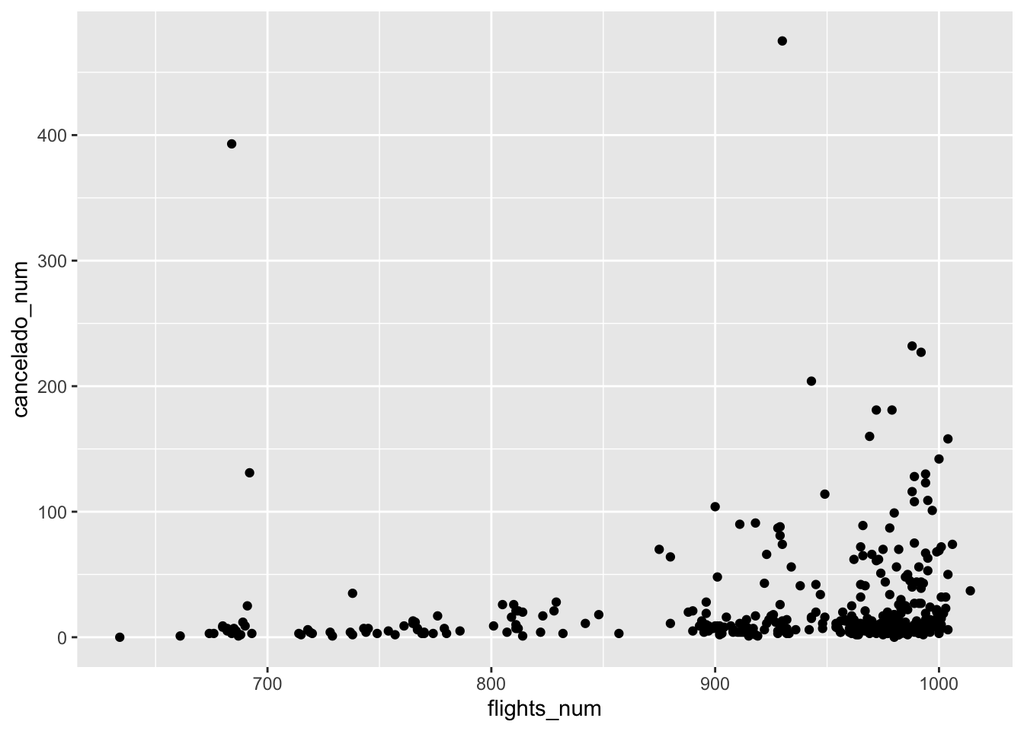

```r
ggplot(cancelado_por_dia) +
  geom_point(aes(x = flights_num, y = cancelado_num))
```

```r
print("A medida que aumentan el número de vuelos en un día, aumenta el número de cancelaciones")
```

```
## [1] "A medida que aumentan el número de vuelos en un día, aumenta el número de cancelaciones"
```

17. Investiga si la proporción de vuelos cancelados está relacionada con el retraso promedio por día en los vuelos.

```r
cancelados_y_retrasos <-
  vuelos %>%
  mutate(cancelado = (is.na(arr_delay) | is.na(dep_delay))) %>%
  group_by(year, month, day) %>%
  summarise(
    prop_cancelado = mean(cancelado),
    media_dep_delay = mean(dep_delay, na.rm = TRUE),
    media_arr_delay = mean(arr_delay, na.rm = TRUE)
  ) %>%
  ungroup()
```

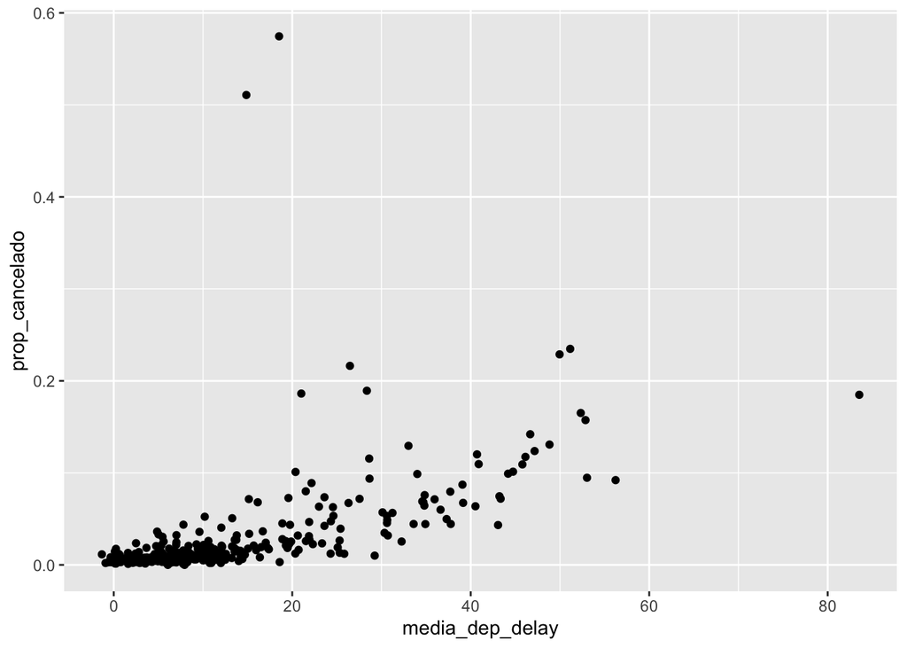

```r
ggplot(cancelados_y_retrasos) +
  geom_point(aes(x = media_dep_delay, y = prop_cancelado))
```

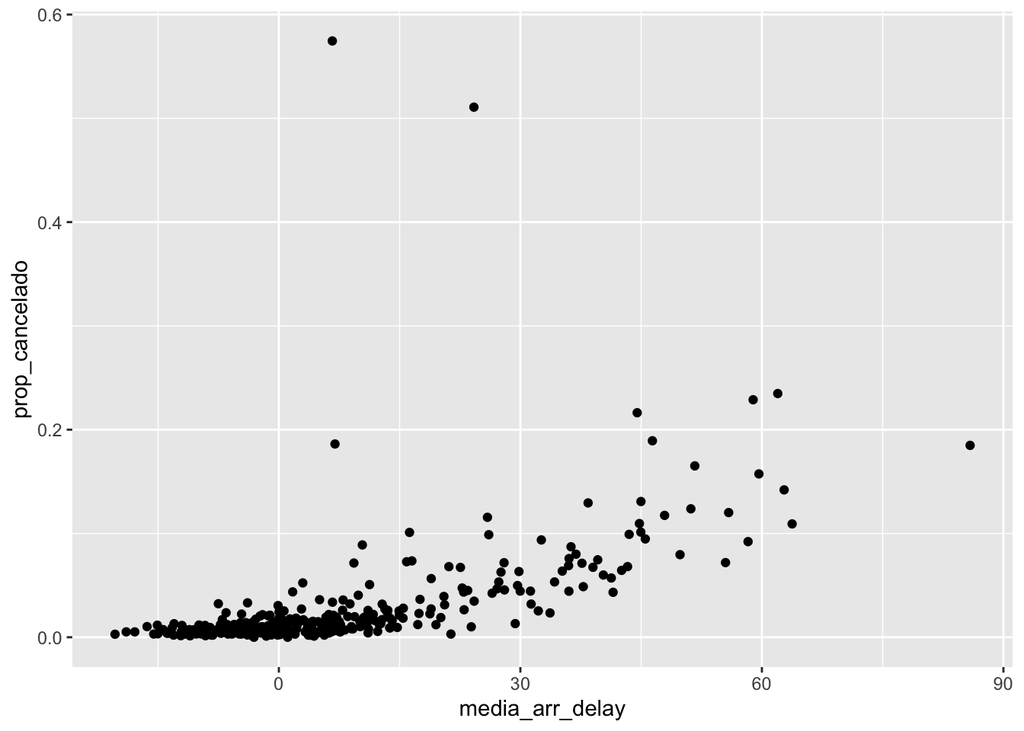

```r
ggplot(cancelados_y_retrasos) +
  geom_point(aes(x = media_arr_delay, y = prop_cancelado))
```

```r
print("Podemos observar que hay una fuerte tendencia lineal de los datos en ambas gráficas por lo que la proporción de vuelos cancelados y los retrasados en la salida y en la llegada están relacionados")
```

```
## [1] "Podemos observar que hay una fuerte tendencia lineal de los datos en ambas gráficas por lo que la proporción de vuelos cancelados y los retrasados en la salida y en la llegada están relacionados"
```

18. Investiga si la proporción de vuelos cancelados está relacionada con el retraso promedio por aeropuerto en los vuelos.

```r
cancelados_y_retrasos_A <-
  vuelos %>%
  mutate(cancelado = (is.na(arr_delay) | is.na(dep_delay))) %>%
  group_by(origin, dest) %>%
  summarise(
    prop_cancelado = mean(cancelado),
    media_dep_delay = mean(dep_delay, na.rm = TRUE),
    media_arr_delay = mean(arr_delay, na.rm = TRUE)
  ) %>%
  ungroup()
```

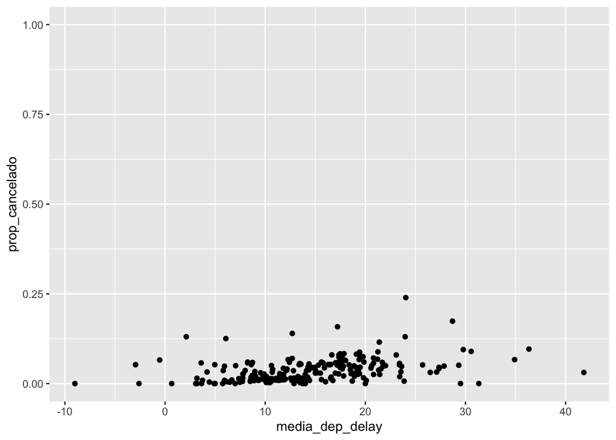

```r
ggplot(cancelados_y_retrasos_A) +
  geom_point(aes(x = media_dep_delay, y = prop_cancelado))
```

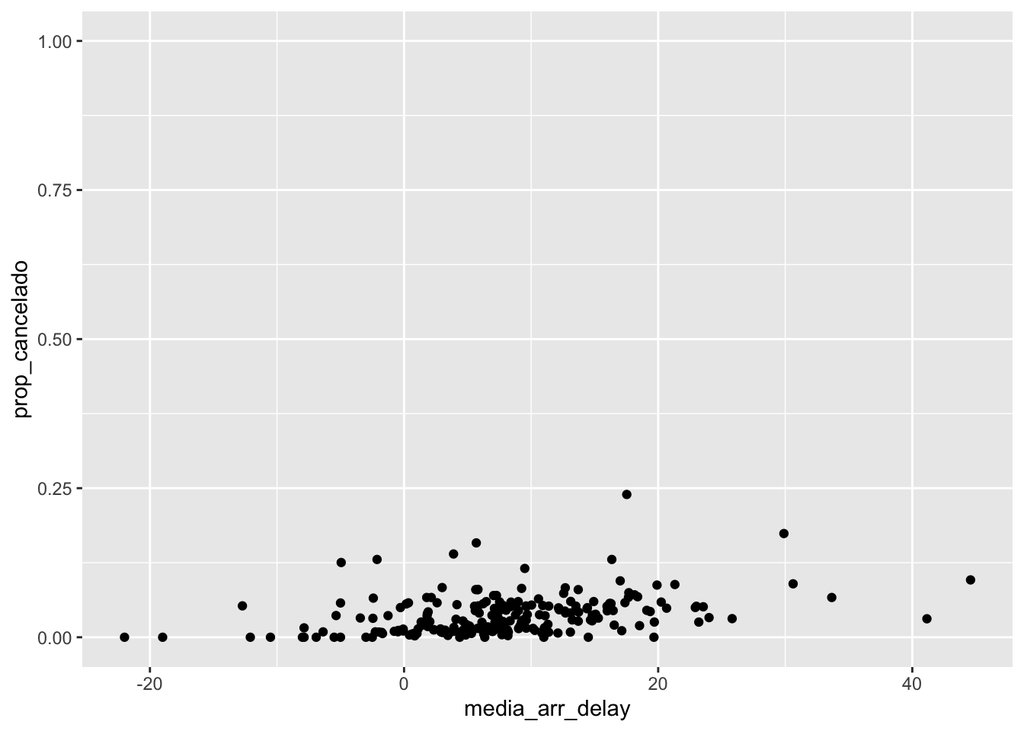

```r
ggplot(cancelados_y_retrasos_A) +
  geom_point(aes(x = media_arr_delay, y = prop_cancelado))
```

```r
print("Podemos observar que en ambos casos hay una pequeña relación ya que a medida que aumnetan los retrasos, aumentan el número de cancelaciones por aeropuerto")
```

```
## [1] "Podemos observar que en ambos casos hay una pequeña relación ya que a medida que aumnetan los retrasos, aumentan el número de cancelaciones por aeropuerto"
```

19. ¿Qué compañía aérea sufre los peores retrasos?

```r
vuelos %>%
  group_by(carrier) %>%
  summarise(arr_delay = mean(arr_delay, na.rm = TRUE)) %>%
  arrange(desc(arr_delay))
```

```
## # A tibble: 16 × 2
##    carrier arr_delay
##    <chr>       <dbl>
##  1 F9         21.9
##  2 FL         20.1
##  3 EV         15.8
##  4 YV         15.6
##  5 OO         11.9
##  6 MQ         10.8
##  7 WN          9.65
##  8 B6          9.46
##  9 9E          7.38
## 10 UA          3.56
## 11 US          2.13
## 12 VX          1.76
## 13 DL          1.64
## 14 AA          0.364
## 15 HA         -6.92
## 16 AS         -9.93
```

```r
vuelos %>%
  group_by(carrier) %>%
  summarise(dep_delay = mean(dep_delay, na.rm = TRUE)) %>%
  arrange(desc(dep_delay))
```

```
## # A tibble: 16 × 2
##    carrier dep_delay
##    <chr>       <dbl>
##  1 F9          20.2
##  2 EV          20.0
##  3 YV          19.0
##  4 FL          18.7
##  5 WN          17.7
##  6 9E          16.7
##  7 B6          13.0
##  8 VX          12.9
##  9 OO          12.6
## 10 UA          12.1
## 11 MQ          10.6
## 12 DL           9.26
## 13 AA           8.59
## 14 AS           5.80
## 15 HA           4.90
## 16 US           3.78
```

```r
print("La F9 es la que más se retrasa tanto en salidas como en llegadas")
```

```
## [1] "La F9 es la que más se retrasa tanto en salidas como en llegadas"
```

20. Queremos saber qué hora del día nos conviene volar si queremos evitar los retrasos en la salida.

```r
vuelos %>%
  group_by(hour) %>%
  summarise(dep_delay = mean(dep_delay, na.rm = TRUE)) %>%
  arrange(dep_delay)
```

```
## # A tibble: 20 × 2
##     hour dep_delay
##    <dbl>     <dbl>
##  1     5     0.688
##  2     6     1.64
##  3     7     1.91
##  4     8     4.13
##  5     9     4.58
##  6    10     6.50
##  7    11     7.19
##  8    12     8.61
##  9    13    11.4
## 10    14    13.8
## 11    23    14.0
## 12    15    16.9
## 13    16    18.8
## 14    22    18.8
## 15    17    21.1
## 16    18    21.1
## 17    21    24.2
## 18    20    24.3
## 19    19    24.8
## 20     1   NaN
```

```r
print("Para evitar los retrasos en la salida la mejor hora para volar son las 5 de la mañana")
```

```
## [1] "Para evitar los retrasos en la salida la mejor hora para volar son las 5 de la mañana"
```

21. Queremos saber qué día de la semana nos conviene volar si queremos evitar los retrasos en la salida.

```r
make_datetime_100 <- function(year, month, day, time)
{
  make_datetime(year, month, day, time %/% 100, time %% 100)
  }

flights_dt <- vuelos %>%
  filter(!is.na(dep_time), !is.na(arr_time)) %>%
  mutate( dep_time = make_datetime_100(year, month, day, dep_time),
          arr_time = make_datetime_100(year, month, day, arr_time),
          sched_dep_time = make_datetime_100(year, month, day, sched_dep_time),
          sched_arr_time = make_datetime_100(year, month, day, sched_arr_time) ) %>%
  select(origin, dest, ends_with("delay"), ends_with("time"))

flights_dt2<- flights_dt %>%
  mutate(dow = wday(sched_dep_time)) %>%
  group_by(dow) %>%
  summarise(
    dep_delay = mean(dep_delay),
    arr_delay = mean(arr_delay, na.rm = TRUE)
  ) %>%
  print(n = Inf)
```

```
## # A tibble: 7 × 3
##     dow dep_delay arr_delay
##   <dbl>     <dbl>     <dbl>
## 1     1     11.5       4.82
## 2     2     14.7       9.65
## 3     3     10.6       5.39
## 4     4     11.7       7.05
## 5     5     16.1      11.7
## 6     6     14.7       9.07
## 7     7      7.62     -1.45
```

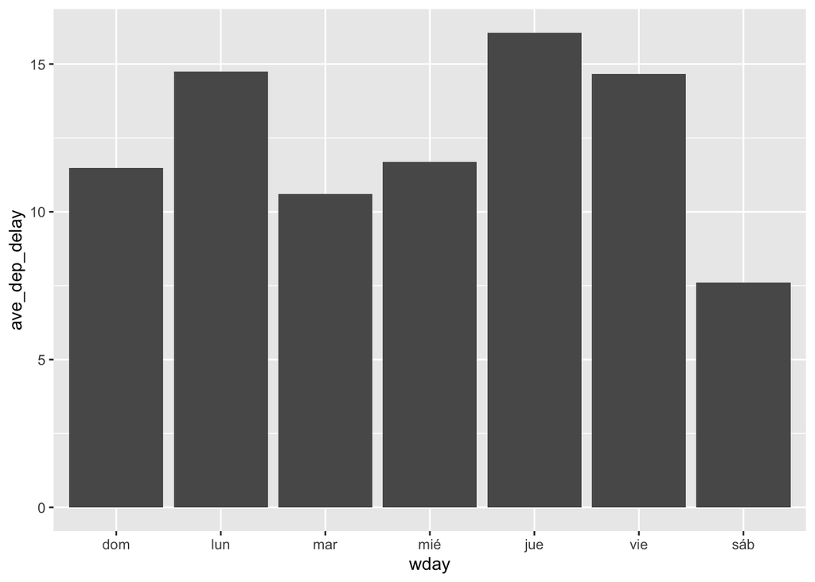

```r
flights_dt %>%
  mutate(wday = wday(dep_time, label = TRUE)) %>% #porque de dep_time
  group_by(wday) %>%
  summarize(ave_dep_delay = mean(dep_delay, na.rm = TRUE)) %>%
  ggplot(aes(x = wday, y = ave_dep_delay)) +
  geom_bar(stat = "identity")
```

```r
print("El sábado es el día de la semana que menos retrasos en la salida hay")
```

```
## [1] "El sábado es el día de la semana que menos retrasos en la salida hay"
```

22. Para cada destino, calcula el total de minutos de retraso acumulado.

```r
retraso_acum<- vuelos %>%
  filter(arr_delay > 0) %>%
  group_by(dest) %>%
  summarise(total_delay= sum(arr_delay))%>%
  arrange(total_delay)
view(retraso_acum)
```

23. Para cada uno de ellos, calcula la proporción del total de retraso para dicho destino.

```r
totalretra= sum(retraso_acum$total_delay)
retraso_acum2<- vuelos %>%
  filter(arr_delay > 0) %>%
  group_by(dest) %>%
  summarise(total_delay= sum(arr_delay),
            prop_total_delay= total_delay / totalretra)%>%
  arrange(prop_total_delay)
view(retraso_acum2)
```

24. Es hora de aplicar todo lo que hemos aprendido para visualizar mejor los tiempos de salida para vuelos cancelados vs los no cancelados. Recuerda bien qué tipo de dato tenemos en cada caso. ¿Qué deduces acerca de los retrasos según la hora del día a la que está programada el vuelo de salida?

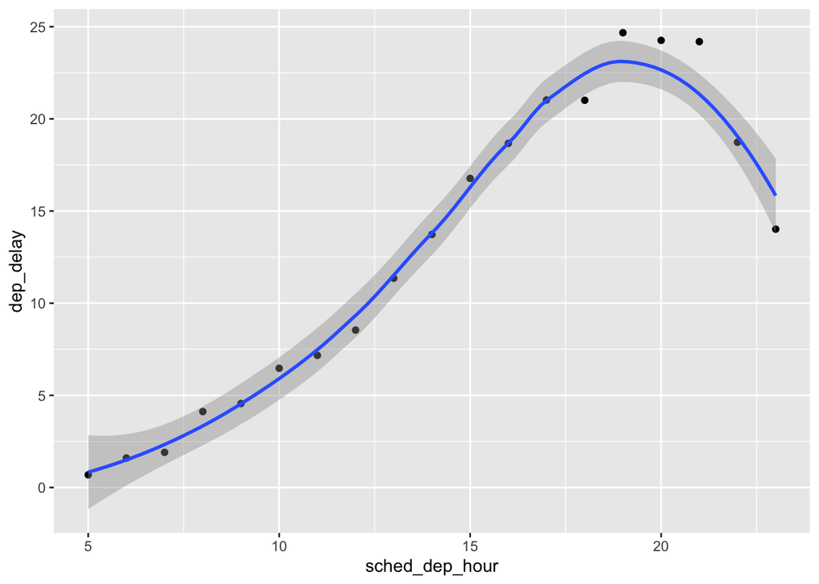

```r
flights_dt %>%
  mutate(sched_dep_hour = hour(sched_dep_time)) %>% #ERROR!!!!!!!!!!!!!!!!!!!!!!!!!!!!!
  group_by(sched_dep_hour) %>%
  summarise(dep_delay = mean(dep_delay)) %>%
  ggplot(aes(y = dep_delay, x = sched_dep_hour)) +
  geom_point() + geom_smooth()
```

```r
print("Podemos observar que a lo largo del día el número de retrasos va aummentando y que al pasar las 20:00 esta tendencia comienza a cambiar disminuyendo los retrasos en los vuelos")
```

```
## [1] "Podemos observar que a lo largo del día el número de retrasos va aummentando y que al pasar las 20:00 esta tendencia comienza a cambiar disminuyendo los retrasos en los vuelos"
```

25. Subir la carpeta a github y facilitar la url.

```r
print("Este es el link de github: https://github.com/jonnn13/Trabajo_Personal.git")
```

```
## [1] "Este es el link de github: https://github.com/jonnn13/Trabajo_Personal.git"
```